# Desafio Final: Tempo de Estudos das populações urbanas e rurais

Graziela Dumard

2022-12-02

## Introdução

Relatório do Desafio Final desenvolvido como parte das atividades do curso de Introdução aos Indicadores com R.

## Objetivo

Apresentar uma análise exploratória inicial que correlaciona os dados de “anos de estudo” com o “IDHM_R” e “IDHM” das populações urbana e rural para tentar compreender se há relação entre tempo de estudo e IDHM e IDHM_R nas populações rural e urbana.

## Apresentação dos dados

O primeiro gráfico refere-se a Relação IDHM e IDHM_R e a proporção dos anos de estudo*.*

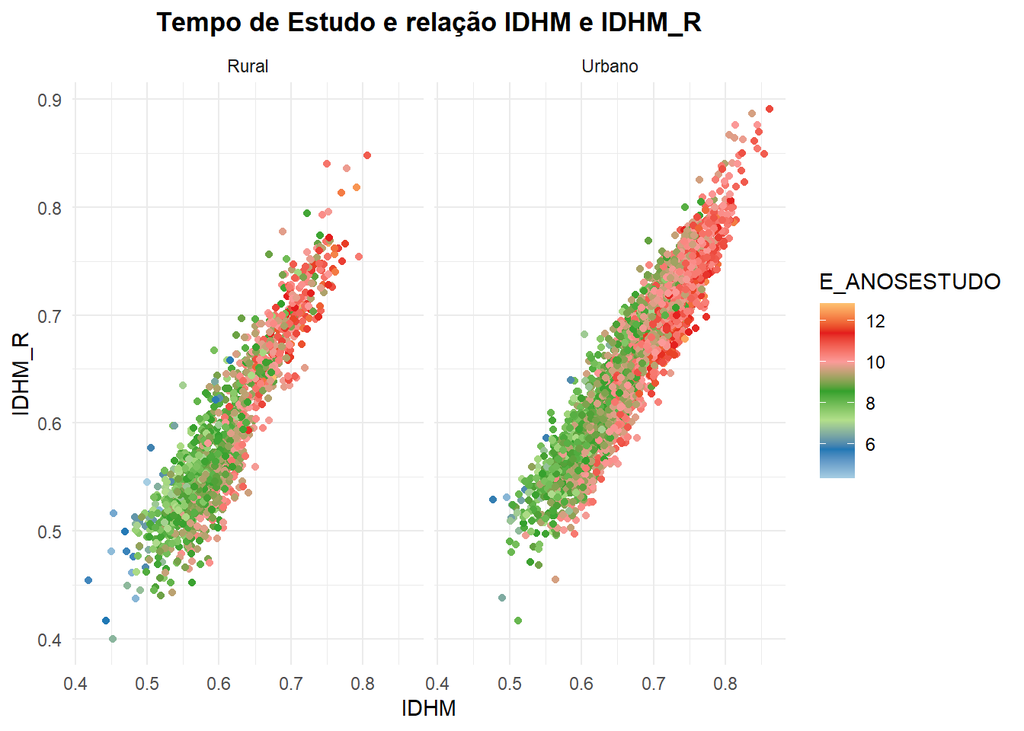

```r
ggplot(juncao1_censo_reg) +
  aes(x = IDHM, y = IDHM_R, colour = E_ANOSESTUDO) +
  geom_point(shape = "circle", size = 1.5) +
  scale_color_distiller(palette = "Paired", direction = 1) +
  labs(title = "Tempo de Estudo e relação IDHM e IDHM_R") +
  theme_minimal() +
  theme(plot.title = element_text(face = "bold", hjust = 0.5)) +
  facet_wrap(vars(urbano_rural))
```

O segundo gráfico faz uma aproximação e relaciona apenas as variáveis IDHM_R e Anos de Estudo.

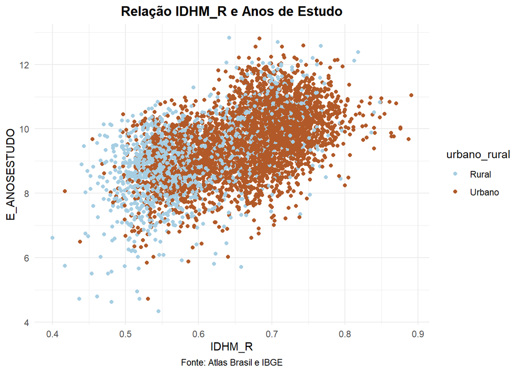

```r
ggplot(juncao1_censo_reg) +
  aes(x = IDHM_R, y = E_ANOSESTUDO, colour = urbano_rural) +
  geom_point(shape = "circle", size = 1.5) +
  scale_color_manual(
    values = c(Rural = "#A6CEE3",
    Urbano = "#B15928")
  ) +
  labs(
    title = "Relação IDHM_R e Anos de Estudo",
    caption = "Fonte: Atlas Brasil e IBGE"
  ) +
  theme_minimal() +
  theme(
    plot.title = element_text(face = "bold",
    hjust = 0.5),
    plot.caption = element_text(hjust = 0.5)
  )
```

## Conclusão

No gráfico 1 observa-se que quanto maior o IDHM e o IDHM_R, maior o tempo de estudo que os indivíduos possuem e isso ocorre em ambas as localizações - urbano e rural. Na localização rural, ambos IDHM e IDHM_R são menores do que na localização urbana. E o tempo estudo é maior e mais concentrado na localização urbana, conforme podemos observar.

Outra observação é no eixo rural há o aparecimento de maior incidência de casos com tempo menor de estudo, abaixo da marca de seis anos, isto é, na cor azul. Este tempo caracterizaria o período do Ensino Fundamental I, até sexto ano. Já no eixo urbano, embora apareçam esses casos, na cor azul, nota-se que há uma predominância para acima de 6 anos, qque se refere as cores verdes.

Além disso, o tempo de estudo acima de 10 anos, que referiria ao Ensino básico e incluiria o Ensino Superior, possui maior predominância na área urbana.

No Gráfico 2, apenas o IDHM_R foi usado como parâmetro para análise do tempo de estudo. E, mais uma vez, ele se mostra predominante em áreas urbanas e influenciando tempo de estudo. Contudo, não se pode deixar de observar que há uma “mancha azul”(rural) misturando ao marrom(urbana), entre os IDHM_R médio e alto, quanto ao tempo de estudo 8 a 10 anos.Isso poderia significar que os indivíduos dessas populações nesses IDHM_R possuem Ensino Médio completo e uma considerável parte acessou o Ensino Superior.

Algumas perguntas ficam em nosso radar que podem ser aprofundadas: O tempo de estudo é maior porque o IDHM e IDHM_R são maiores ou é devido ao tempo de estudo de o IDHM e IDHM_R são maiores? Outro questionamento é a migração do eixo rural para o urbano, será que isso impacta o aumento nos índices urbanos? E quanto ao retorno para o âmbito rural? Isso poderia explicar essa mancha azul entre os IDHM_R médio rural?

Essas são conclusões iniciais, e questionamentos que podem ser explorados com os dados.